# Building a realtime anomaly detector

### By: Peter Tillotson [( Acumed Consulting Ltd )](https://acumedconsulting.com)

| Part | Learning Objectives |
| --- | --- |
| 1 | Setting up your dev environment and getting some data to work with |
| 2 | Learning to read and process data |
| 3 | Simple linear regression, building stats based detectors |
| 4 | Understanding seaonality |

At the end of the season you should have built a realtime detector.

## About me

- Lead data analyst at Riot Games
- Pasionate about Gaming Analytics
- Set up and run the London Gaming Analytics Meetup
- Have done a bunch of Security work too
- Learning to play drums
- PhD Distributed intelligent agents
- 20yrs experience R&D making things fast

# Part 1

> Develpment environment setup

tl;dr:

- Create a virtual environment for our project
- Install all the project dependencies
- Pull down and extract some data to play with

## A note on Python versions

**Always Python 3+** These days I would recommend Python 3.6 and above.

Python 2.7 persists because its used in quite a few Linux distros to manage packages, OS scripts etc.

If you can use Python 3 do so, occasionally there is a package that does not support Python 3, it is rare these day and may be because its not maintained or there alternatives that have superceded in 3.

> tl;dr we need to let go of 2.7

### Virtual Environments

Are clean Python virtual install, they are actually simlinks to your main Python install, but they don't have any installed packages. This means when working on lots of projects fewer dependency conflicts.

```
base> pip install virtualenv
base> virtualenv -p python3 venv
base> source venv/bin/activate
venv> pip install -r requirements.txt
```

On Windows I would advise the Anaconda install of Python generally, some things are easier with this install. It has a built in version to.

https://towardsdatascience.com/getting-started-with-python-environments-using-conda-32e9f2779307

I prefer virtualenv, as I work on Mac, Linux and Windows.

On Windows the activate is `.\venv\Scripts\activate.bat`

### Project Dependencies

The convention is for Python projects to have a `requirements.txt` in there base directory, often alongside a `distutils` `setup.py` file. You can specify packages your project depend on in this file, or you can.

```
venv> pip install pandas jupyter scipy
venv> pip freeze > requirements.txt
```

Which creates the requirements file from currently installed packages.

These can be installed with

```
venv> pip install -r requirements.txt
```

### **Excercise 1a**

Todo:

- Create a new project directory, change into it
- Get your virtualenv created pointing to a Python3 install
- Switch into your new virtual environment
- Download and install the requirements in you virtual env

### **Excercise 1b**

Todo:

- Create two folders in your project `data` and `notebooks`
- Get data: https://github.com/numenta/NAB/archive/v1.0.zip
  - If you raced through the last bit get data programatically
  - Else download manually and unpack into data

```python
import requests, zipfile, io, os, glob, shutil

from os.path import exists, join, split

prefix = 'NAB-1.0/data'
data_dir = '../data'
fd_done = 'success.txt'

if exists( join(data_dir, fd_done) ) == False:
    if exists(data_dir) == False:
        os.mkdir(data_dir)

    url = 'https://github.com/numenta/NAB/archive/v1.0.zip'
    r = requests.get(url)

    with zipfile.ZipFile(io.BytesIO(r.content)) as z:
        for n in z.namelist():
            if n.startswith(prefix) and n.endswith('csv'):
                z.extract(n, path=data_dir)

    path = join(data_dir, prefix, '*')
    for n in glob.glob(path):
        head, tail = split(n)
        new_path = join(data_dir, tail)
        shutil.move(n, new_path)
    head, tail = split(join(data_dir, prefix))
    shutil.rmtree(head)
    with open(join(data_dir, fd_done), 'w') as fd:
        fd.write('done')
else:
    print('data already pulled')
```

```
data already pulled
```

We did it

[figure not shown]

# Part 2

> Read and process data

tl;dr:

- Read data with Python Pandas
- Simple plot with Matplotlib and Plotly
- Interpolate and
- Resample

```python
import pandas as pd

# timestamp,value
# 2015-02-26 21:42:53,35
# 2015-02-26 21:47:53,41
# 2015-02-26 21:52:53,32
# 2015-02-26 21:57:53,36
# 2015-02-26 22:02:53,32

df = pd.read_csv('../data/realTweets/Twitter_volume_GOOG.csv',
    index_col=0,
    parse_dates=True
)
df.head(5)
```

| timestamp | value |
| --- | --- |
| 2015-02-26 21:42:53 | 35 |
| 2015-02-26 21:47:53 | 41 |
| 2015-02-26 21:52:53 | 32 |
| 2015-02-26 21:57:53 | 36 |
| 2015-02-26 22:02:53 | 32 |

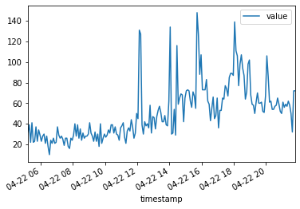

```python
import matplotlib
%matplotlib inline

df.tail(200).plot()
```

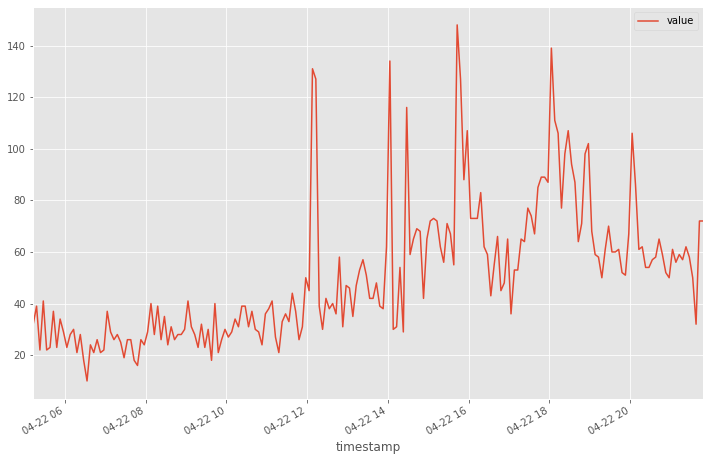

```python
matplotlib.rcParams['figure.figsize'] = (12.0, 8.0)
matplotlib.style.use('ggplot')
df.tail(200).plot()
```

```python
import plotly.graph_objects as go
fig = go.Figure()
fig.add_trace(go.Scatter(
        x=df.tail(200).index,
        y=df.tail(200).value,
        mode='lines'
))
fig.show(config={'displaylogo':False})
```

[interactive chart not shown]

### Handling dirty data

> Data science is 50% ETL

The data is never quite right, and we have to accept that. In the next few slides we will look at handling two common problems.

#### Resampling

Used to get data onto a common interval between samples

#### Interpolation

Somtimes needed when you have holes in your data, these can be caused by resampling or just inherant in the data.

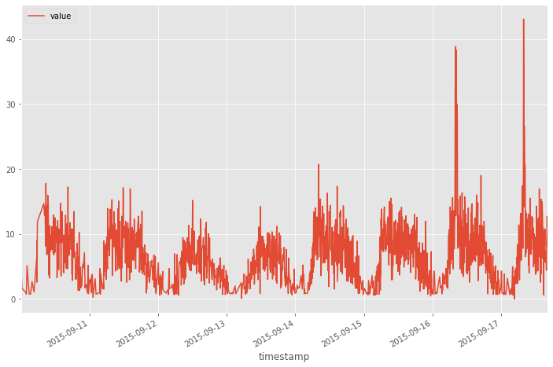

```python
fd = '../data/realTraffic/occupancy_t4013.csv'
df = df = pd.read_csv(fd,
    index_col=0,
    parse_dates=True
)
#df = df['2015-04-10':]
df = df['2015-09-10':]
df.plot()
```

```python
df.head(10).reset_index().transpose()
```

|  | 0 | 1 | 2 | 3 | 4 | 5 | 6 | 7 | 8 | 9 |
| --- | --- | --- | --- | --- | --- | --- | --- | --- | --- | --- |
| timestamp | 2015-09-10 00:03:00 | 2015-09-10 00:13:00 | 2015-09-10 00:18:00 | 2015-09-10 00:23:00 | 2015-09-10 01:48:00 | 2015-09-10 01:53:00 | 2015-09-10 02:08:00 | 2015-09-10 02:53:00 | 2015-09-10 03:22:00 | 2015-09-10 03:52:00 |
| value | 2.61 | 3.06 | 2.11 | 1.61 | 0.94 | 0.72 | 5.11 | 0.78 | 0.72 | 2.67 |

```python
df.head(10).reset_index().diff().transpose()
```

|  | 0 | 1 | 2 | 3 | 4 | 5 | 6 | 7 | 8 | 9 |
| --- | --- | --- | --- | --- | --- | --- | --- | --- | --- | --- |
| timestamp | NaT | 0 days 00:10:00 | 0 days 00:05:00 | 0 days 00:05:00 | 0 days 01:25:00 | 0 days 00:05:00 | 0 days 00:15:00 | 0 days 00:45:00 | 0 days 00:29:00 | 0 days 00:30:00 |
| value | NaT | 0.45 | -0.95 | -0.5 | -0.67 | -0.22 | 4.39 | -4.33 | -0.06 | 1.95 |

Commands:

- **head** : take the first n rows
- **reset_index**: without options turns the index into a column (needed here for diff to work)
- **diff**: Difference, from one row to the next
- **transpose**: Turn each column into a row

**Note**: The difference between original dataframe sampling time is all over the place. In your application it is up to your judgement as to whether this matters.

In this case to fix it I would resample at perhaps 15 or 30mins.

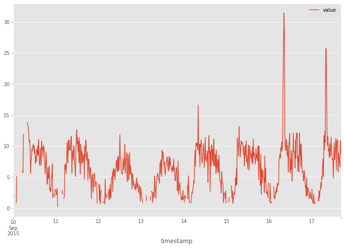

```python
s_rule = '15T' # 15 mins
sf = df.resample(s_rule).mean() # You need to choose how to aggregate
sf.plot()
```

Oops, we now have holes in the data

```python
sf.head(10).reset_index().transpose()
```

|  | 0 | 1 | 2 | 3 | 4 | 5 | 6 | 7 | 8 | 9 |
| --- | --- | --- | --- | --- | --- | --- | --- | --- | --- | --- |
| timestamp | 2015-09-10 00:00:00 | 2015-09-10 00:15:00 | 2015-09-10 00:30:00 | 2015-09-10 00:45:00 | 2015-09-10 01:00:00 | 2015-09-10 01:15:00 | 2015-09-10 01:30:00 | 2015-09-10 01:45:00 | 2015-09-10 02:00:00 | 2015-09-10 02:15:00 |
| value | 2.835 | 1.86 | NaT | NaT | NaT | NaT | NaT | 0.83 | 5.11 | NaT |

We can fill the holes with interpolation. There are lots of methods including `quadratic`, `polynomial`.

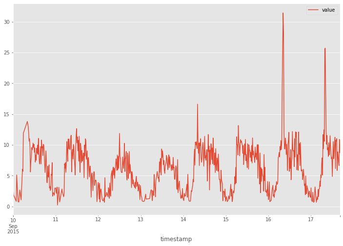

```python
sf.interpolate(method='time',inplace=True)
sf.plot()
```

```python
sf.head(10).reset_index().transpose()
```

|  | 0 | 1 | 2 | 3 | 4 | 5 | 6 | 7 | 8 | 9 |
| --- | --- | --- | --- | --- | --- | --- | --- | --- | --- | --- |
| timestamp | 2015-09-10 00:00:00 | 2015-09-10 00:15:00 | 2015-09-10 00:30:00 | 2015-09-10 00:45:00 | 2015-09-10 01:00:00 | 2015-09-10 01:15:00 | 2015-09-10 01:30:00 | 2015-09-10 01:45:00 | 2015-09-10 02:00:00 | 2015-09-10 02:15:00 |
| value | 2.835 | 1.86 | 1.68833 | 1.51667 | 1.345 | 1.17333 | 1.00167 | 0.83 | 5.11 | 3.66667 |

### **Excercise 2:** Your turn

Todo:

- Read file using pandas `../data/realTraffic/occupancy_t4013.csv`
- Resample hourly, assuming the value is number of items purchased
- Do you need to interpolate?
- Plot the raw and resampled data

We did it again

[figure not shown]